# Notebook

**📺 Breaking Bad Viewership Report 📺**

Shokhrukhbek Valijonov

[figure not shown]

## ✨ *About the Show*

**Breaking Bad** is an American television series created by *Vince Gilligan* that aired on AMC from 2008 to 2013. The series stars **Bryan Cranston** as *Walter White*, a chemistry teacher which due to lung cancer diagnosis turned into a crime warlord. The observer may perceive the route through which Walter undergoes as he firstly just strive to ensure financial stability for his family but then gets corrupted and dragged into a violent criminal world alngoside with his former student Jessy Pinkmen with whom he strated cooking methaamphetamine at the beginning. Breaking Bad stars such personas as Anna Gunn, Dean Norris, RJ Mitte, Betsy Brandt, Giancarlo Esposito, Jonathan Banks, and Bob Odenkirk who became the main actor for TV-show spinoff of Breaking Bad called "Better Call Saul". The show received widespread critical acclaim and is considered one of the greatest TV shows of all time.

## 📊 Viewership Data and Summary Statistics

```python
import pandas as pd

# Viewership data (average viewers per season, in millions)
data = {
    'Season': [1, 2, 3, 4, 5],
    'Episodes': [7, 13, 13, 13, 16],
    'Avg_Viewers_M': [1.41, 1.30, 1.52, 1.90, 4.32]
}

df = pd.DataFrame(data)
df
```

|  | Season | Episodes | Avg_Viewers_M |
| --- | --- | --- | --- |
| 0 | 1 | 7 | 1.41 |
| 1 | 2 | 13 | 1.30 |
| 2 | 3 | 13 | 1.52 |
| 3 | 4 | 13 | 1.90 |
| 4 | 5 | 16 | 4.32 |

```python
print("📊 Basic Viewership Stats\n")

print(f"Total Seasons: {df['Season'].nunique()}")
print(f"Total Episodes: {df['Episodes'].sum()}")
print(f"Average Viewership (all seasons): {df['Avg_Viewers_M'].mean():.2f} million") # this part was corrected by Chat GPT
print(f"Highest Avg Viewership: {df['Avg_Viewers_M'].max():.2f} million (Season {df.loc[df['Avg_Viewers_M'].idxmax(), 'Season']})") # this part was corrected by Chat GPT
print(f"Lowest Avg Viewership: {df['Avg_Viewers_M'].min():.2f} million (Season {df.loc[df['Avg_Viewers_M'].idxmin(), 'Season']})") # this part was corrected by Chat GPT
```

```
📊 Basic Viewership Stats

Total Seasons: 5
Total Episodes: 62
Average Viewership (all seasons): 2.09 million
Highest Avg Viewership: 4.32 million (Season 5)
Lowest Avg Viewership: 1.30 million (Season 2)
```

```python
ratings = {
    1: [9.0, 8.6, 8.7, 8.2, 8.3, 9.3, 8.8],
    2: [8.6, 9.3, 8.8, 8.2, 8.8, 8.6, 9.2, 9.2, 8.4, 8.9, 9.3, 9.2, 9.1],
    3: [8.5, 8.6, 8.4, 8.2, 8.5, 9.3, 9.6, 8.7, 7.9, 8.4, 9.5, 9.7, 9.0],
    4: [9.2, 8.2, 8.0, 8.8, 9.3, 9.0, 9.7, 9.0, 9.5, 9.9, 9.3, 9.5, 9.9],
    5: [9.2, 8.8, 8.8, 8.8, 9.7, 9.0, 9.6, 9.4, 9.2, 9.6, 9.1, 9.8, 10.0, 9.7, 9.9, 9.9]
}

# Build the DataFrame
all_rows = []
for season, season_ratings in ratings.items():
    for ep_num, rating in enumerate(season_ratings, start=1):
        all_rows.append({'Season': season, 'Episode': ep_num, 'Rating': rating})

df_all = pd.DataFrame(all_rows)

# Show the first few rows (not just Season 1)
df_all.head(62)
```

|  | Season | Episode | Rating |
| --- | --- | --- | --- |
| 0 | 1 | 1 | 9.0 |
| 1 | 1 | 2 | 8.6 |
| 2 | 1 | 3 | 8.7 |
| 3 | 1 | 4 | 8.2 |
| 4 | 1 | 5 | 8.3 |
| ... | ... | ... | ... |
| 57 | 5 | 12 | 9.8 |
| 58 | 5 | 13 | 10.0 |
| 59 | 5 | 14 | 9.7 |
| 60 | 5 | 15 | 9.9 |
| 61 | 5 | 16 | 9.9 |

62 rows × 3 columns

```python
import matplotlib as plt
import matplotlib.pyplot as plt
```

```python
pivot_df = df_all.pivot(index='Season', columns='Episode', values='Rating')
pivot_df = pivot_df.sort_index(axis=1)

# This part was corrected by Chat GPT

styled_df = pivot_df.style\
    .set_caption("⭐ IMDb Ratings by Season and Episode")\
    .format("{:.1f}", na_rep="–")\
    .background_gradient(cmap="YlOrBr", axis=None)\
    .set_properties(**{'text-align': 'center'})

styled_df
```

⭐ IMDb Ratings by Season and Episode

| Episode Season | 1 | 2 | 3 | 4 | 5 | 6 | 7 | 8 | 9 | 10 | 11 | 12 | 13 | 14 | 15 | 16 |
| --- | --- | --- | --- | --- | --- | --- | --- | --- | --- | --- | --- | --- | --- | --- | --- | --- |
| 1 | 9.0 | 8.6 | 8.7 | 8.2 | 8.3 | 9.3 | 8.8 | – | – | – | – | – | – | – | – | – |
| 2 | 8.6 | 9.3 | 8.8 | 8.2 | 8.8 | 8.6 | 9.2 | 9.2 | 8.4 | 8.9 | 9.3 | 9.2 | 9.1 | – | – | – |
| 3 | 8.5 | 8.6 | 8.4 | 8.2 | 8.5 | 9.3 | 9.6 | 8.7 | 7.9 | 8.4 | 9.5 | 9.7 | 9.0 | – | – | – |
| 4 | 9.2 | 8.2 | 8.0 | 8.8 | 9.3 | 9.0 | 9.7 | 9.0 | 9.5 | 9.9 | 9.3 | 9.5 | 9.9 | – | – | – |
| 5 | 9.2 | 8.8 | 8.8 | 8.8 | 9.7 | 9.0 | 9.6 | 9.4 | 9.2 | 9.6 | 9.1 | 9.8 | 10.0 | 9.7 | 9.9 | 9.9 |

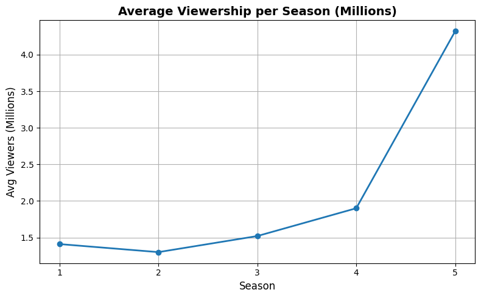

```python
viewership_df = pd.DataFrame({
    'Season': [1, 2, 3, 4, 5],
    'Avg_Viewers_M': [1.41, 1.30, 1.52, 1.90, 4.32]
})

plt.figure(figsize=(8, 5))
plt.plot(viewership_df['Season'], viewership_df['Avg_Viewers_M'], marker='o', linewidth=2)
plt.title("Average Viewership per Season (Millions)", fontsize=14, weight='bold')
plt.xlabel("Season", fontsize=12)
plt.ylabel("Avg Viewers (Millions)", fontsize=12)
plt.grid(True)
plt.xticks(viewership_df['Season'])
plt.tight_layout()
plt.show()
```

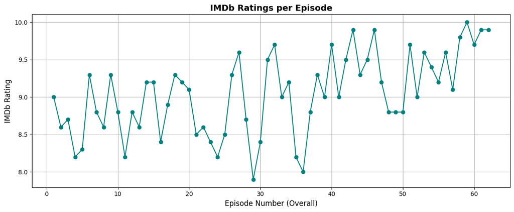

```python
plt.figure(figsize=(12, 5))
plt.plot(df_all.index + 1, df_all['Rating'], marker='o', color='teal', linewidth=1.5)
plt.title("IMDb Ratings per Episode", fontsize=14, weight='bold')
plt.xlabel("Episode Number (Overall)", fontsize=12)
plt.ylabel("IMDb Rating", fontsize=12)
plt.grid(True)
plt.tight_layout()
plt.show()
```

## 📉 Observed Changes in Viewership

```python
viewership_df['Change'] = viewership_df['Avg_Viewers_M'].diff()

viewership_df
```

|  | Season | Avg_Viewers_M | Change |
| --- | --- | --- | --- |
| 0 | 1 | 1.41 | NaN |
| 1 | 2 | 1.30 | -0.11 |
| 2 | 3 | 1.52 | 0.22 |
| 3 | 4 | 1.90 | 0.38 |
| 4 | 5 | 4.32 | 2.42 |

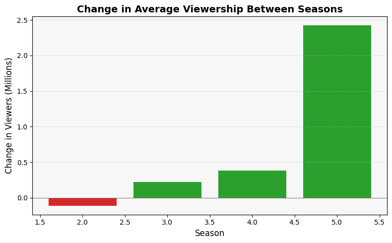

```python
# This part was corrected by Chat GPT

plt.figure(figsize=(8, 5))
bars = plt.bar(viewership_df['Season'][1:], viewership_df['Change'][1:],
               color=['#d62728' if v < 0 else '#2ca02c' for v in viewership_df['Change'][1:]])

plt.axhline(0, color='gray', linewidth=0.8)
plt.title("Change in Average Viewership Between Seasons", fontsize=14, weight='bold')
plt.xlabel("Season", fontsize=12)
plt.ylabel("Change in Viewers (Millions)", fontsize=12)
plt.grid(axis='y', linestyle='--', linewidth=0.5, alpha=0.6)
plt.gca().set_facecolor('#f7f7f7')
plt.tight_layout()
plt.show()
```

The viewership of *Breaking Bad* fluctuated during its five-season run:

- Between **Season 1 and Season 2**, viewership **decreased slightly by 0.11 million** viewers (from 1.41M to 1.30M).
- This was followed by **steady growth**:
  - **Season 2 → 3**: +0.22 million
  - **Season 3 → 4**: +0.38 million
- The **largest increase** occurred between **Season 4 and Season 5**, with an impressive **+2.42 million** viewers (from 1.90M to 4.32M).

This significant growth reflects how popular the show has become during its final seasons. Increasing popularity was due to strong word of mouth, and high critical acclaim which led to Breaking Bad habving the fith in the history most watched final seasons of all time.